# Lab 12

Hemen Khanna

2026-05-11

#### Part 1:

##### Question 1:

The tables I am using are P_AUQ, P_SLQ, P_GHB, and P_FERTIN. The variables I am using are AUQ054, SLQ050, LBXFER, and LBXGH. To clean the data, I will remove skip patterns in categorical variables if they exist. Then, I will classify all values as refused to answer or unknown as missing. Additionally, I will drop participants with values beyond 3 standard deviations of the mean for continuous variables.

##### Question 2:

I expect that the variance will decrease for the continuous variables while the frequency for values recoded as missing will drop to zero.

##### Question 3:

Removing skip patterns and reclassifying values as missing fall into the category of data entry errors while removing outliers falls into the category of cleaning to prevent poor model fits.

#### Part 2:

##### Question 4:

```r
query_select <- dbGetQuery(db, "SELECT SLQ050, AUQ054, LBXFER, LBXGH FROM P_SLQ JOIN P_AUQ ON P_SLQ.SEQN = P_AUQ.SEQN JOIN P_PAQ ON P_PAQ.SEQN = P_AUQ.SEQN JOIN P_ALQ ON P_ALQ.SEQN = P_AUQ.SEQN JOIN P_GHB ON P_GHB.SEQN = P_SLQ.SEQN JOIN P_FERTIN ON P_FERTIN.SEQN = P_AUQ.SEQN")


query_2_clean <- query_select




query_2_clean$SLQ050 <- query_select$SLQ050 %>% replace_values(c(7, 9) ~ NA )
query_2_clean$AUQ054 <- query_select$AUQ054 %>% replace_values(c(77, 99) ~ NA )

mean_fer <- mean(query_2_clean$LBXFER, na.rm = TRUE)
sd_fer <- sd(query_2_clean$LBXFER, na.rm = TRUE)
sd_fer_upper <- mean_fer + (3*sd_fer)
sd_fer_lower <- mean_fer - (3*sd_fer)

if(sd_fer_lower < 0) {

  sd_fer_lower <- 0

}

mean_lbxgh <- mean(query_2_clean$LBXGH, na.rm = TRUE)
sd_lbxgh <- sd(query_2_clean$LBXGH, na.rm = TRUE)
sd_lbxgh_upper <- mean_lbxgh + (3*sd_lbxgh)
sd_lbxgh_lower <- mean_lbxgh - (3*sd_lbxgh)

if(sd_lbxgh_lower < 0) {

  sd_lbxgh_lower <- 0

}


query_2_clean$index <- 1:nrow(query_2_clean)

LBXFER_ol <- query_2_clean %>% select(index, LBXFER) %>% filter(LBXFER > sd_fer_upper | LBXFER < sd_fer_lower)
query_2_clean$LBXFER[LBXFER_ol$index] <- NA

LBXGH_ol <- query_2_clean %>% select(index, LBXGH) %>% filter(LBXGH > sd_lbxgh_upper | LBXGH < sd_lbxgh_lower)
query_2_clean$LBXGH[LBXGH_ol$index] <- NA
```

##### Question 5:

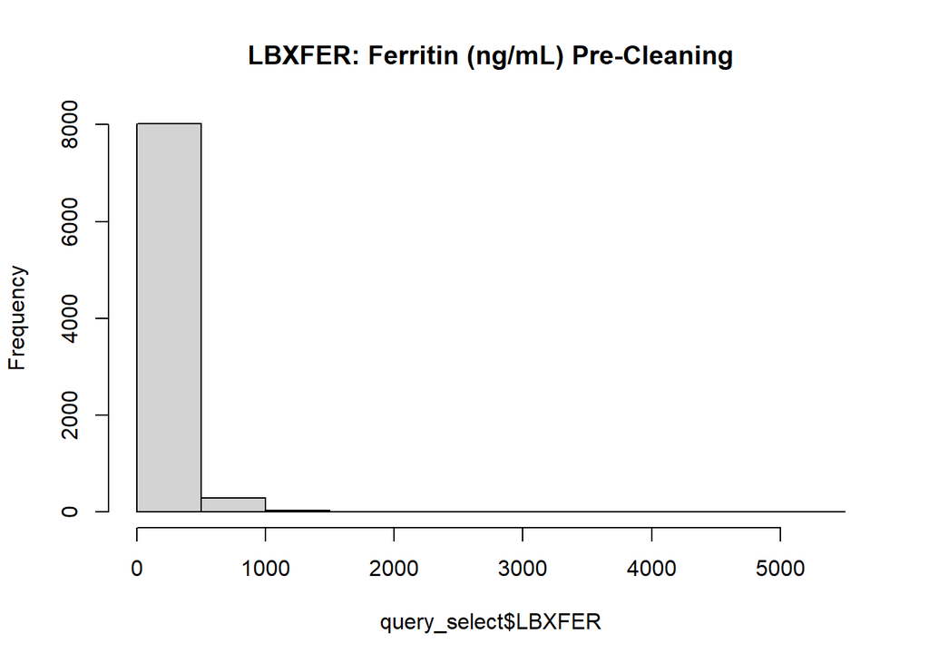

```r
hist(x = query_select$LBXFER, main = "LBXFER: Ferritin (ng/mL) Pre-Cleaning")
```

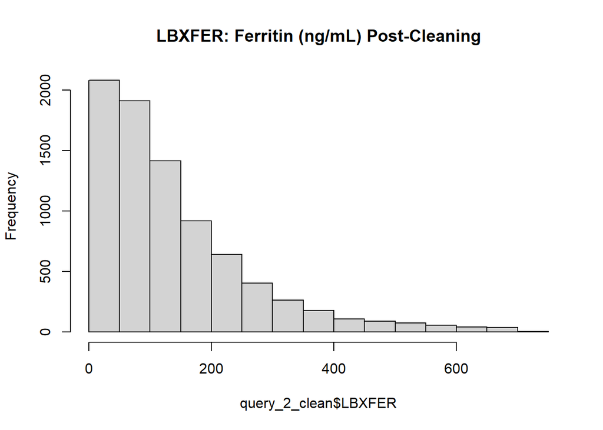

```r
hist(x = query_2_clean$LBXFER, main = "LBXFER: Ferritin (ng/mL) Post-Cleaning")
```

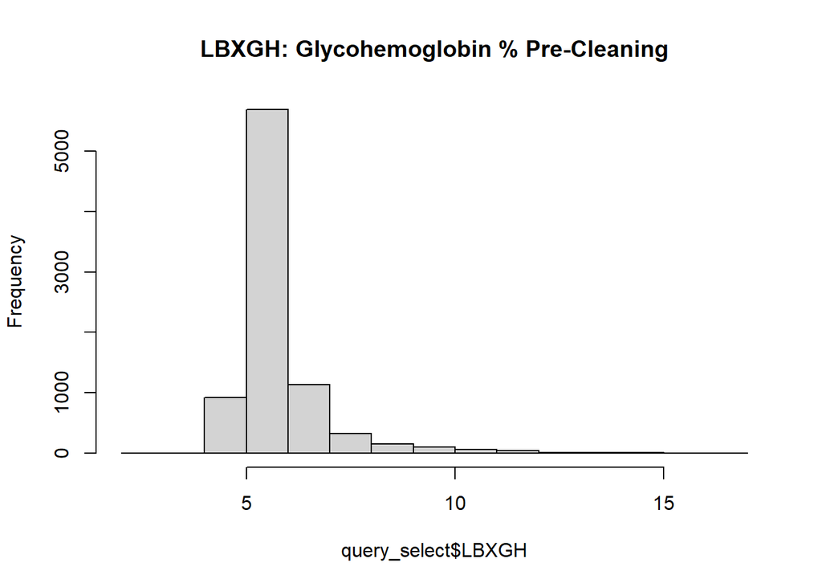

```r
hist(x = query_select$LBXGH, main = "LBXGH: Glycohemoglobin % Pre-Cleaning")
```

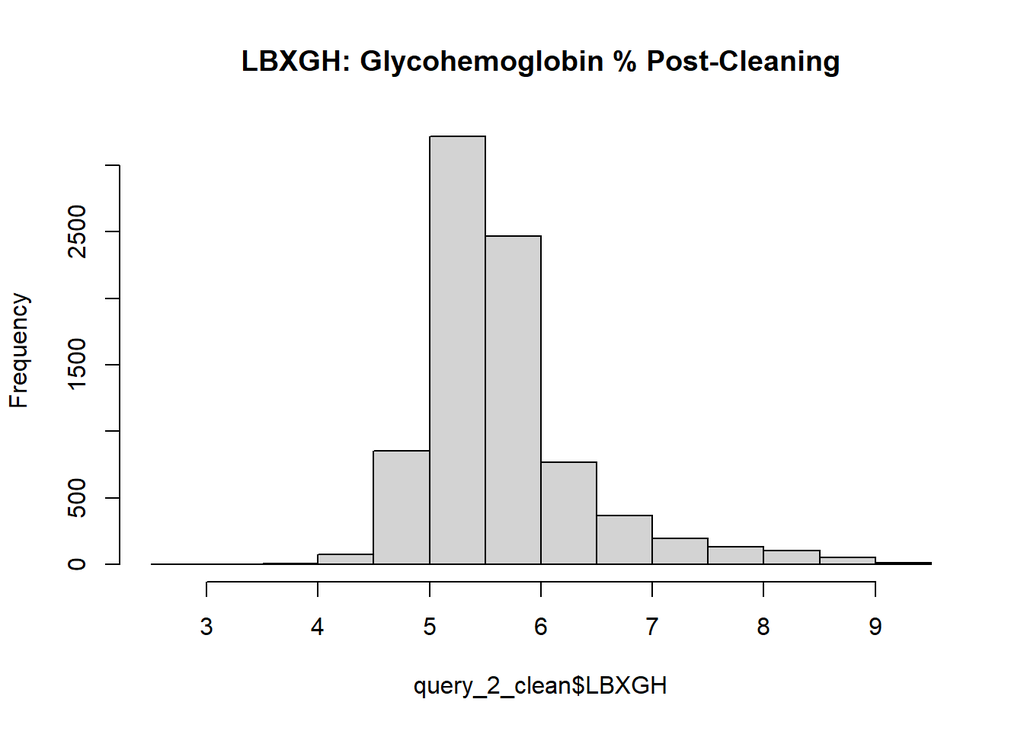

```r
hist(x = query_2_clean$LBXGH, main = "LBXGH: Glycohemoglobin % Post-Cleaning")
```

For the two continuous variables, the data follows my expectations, as the variance has notably decreased post-cleaning as seen by the decreased range in the graphs following the cleaning steps.

##### Question 6:

I would create a CSV file instead of a function, since different variables having missingness coded differently, and I would have to rewrite the function every time I choose new variables to accommodate for that.

Code Appendix:

```r
knitr::opts_chunk$set(echo = TRUE)
library(RSQLite)
library(ggplot2)
library(ggpubr)
library(knitr)
library(summarytools)
library(tidyr)
library(dplyr)

db <- dbConnect(RSQLite::SQLite(), "C:/Users/hkhan/Documents/epi560.sqlite")




query_select <- dbGetQuery(db, "SELECT SLQ050, AUQ054, LBXFER, LBXGH FROM P_SLQ JOIN P_AUQ ON P_SLQ.SEQN = P_AUQ.SEQN JOIN P_PAQ ON P_PAQ.SEQN = P_AUQ.SEQN JOIN P_ALQ ON P_ALQ.SEQN = P_AUQ.SEQN JOIN P_GHB ON P_GHB.SEQN = P_SLQ.SEQN JOIN P_FERTIN ON P_FERTIN.SEQN = P_AUQ.SEQN")


query_2_clean <- query_select




query_2_clean$SLQ050 <- query_select$SLQ050 %>% replace_values(c(7, 9) ~ NA )
query_2_clean$AUQ054 <- query_select$AUQ054 %>% replace_values(c(77, 99) ~ NA )

mean_fer <- mean(query_2_clean$LBXFER, na.rm = TRUE)
sd_fer <- sd(query_2_clean$LBXFER, na.rm = TRUE)
sd_fer_upper <- mean_fer + (3*sd_fer)
sd_fer_lower <- mean_fer - (3*sd_fer)

if(sd_fer_lower < 0) {

  sd_fer_lower <- 0

}

mean_lbxgh <- mean(query_2_clean$LBXGH, na.rm = TRUE)
sd_lbxgh <- sd(query_2_clean$LBXGH, na.rm = TRUE)
sd_lbxgh_upper <- mean_lbxgh + (3*sd_lbxgh)
sd_lbxgh_lower <- mean_lbxgh - (3*sd_lbxgh)

if(sd_lbxgh_lower < 0) {

  sd_lbxgh_lower <- 0

}


query_2_clean$index <- 1:nrow(query_2_clean)

LBXFER_ol <- query_2_clean %>% select(index, LBXFER) %>% filter(LBXFER > sd_fer_upper | LBXFER < sd_fer_lower)
query_2_clean$LBXFER[LBXFER_ol$index] <- NA

LBXGH_ol <- query_2_clean %>% select(index, LBXGH) %>% filter(LBXGH > sd_lbxgh_upper | LBXGH < sd_lbxgh_lower)
query_2_clean$LBXGH[LBXGH_ol$index] <- NA


hist(x = query_select$LBXFER, main = "LBXFER: Ferritin (ng/mL) Pre-Cleaning")
hist(x = query_2_clean$LBXFER, main = "LBXFER: Ferritin (ng/mL) Post-Cleaning")

hist(x = query_select$LBXGH, main = "LBXGH: Glycohemoglobin % Pre-Cleaning")
hist(x = query_2_clean$LBXGH, main = "LBXGH: Glycohemoglobin % Post-Cleaning")
```